# Lab 12: U.S. Election Grid Map

CMSC471: Introduction to Information Visualization (Spring 2026)

**Grade (3% of total course grade)**: This lab is graded out of 30 points. You may submit your lab in person during the lab session on April 29 and May 6, 2026 or during any office hours within this time frame. The final submission deadline is May 7, 2026 at 6:00 PM (ET).

**Submission**: (1) the in-class checkout (2) the folder and chat history as a `.zip` (or similar) to Canvas!

## How to approach this lab

This lab has two tracks — pick one and stick with it.

**Track 1 — Follow the instructions**: Work through Parts 1–5 in order. Read the explanations, run the code, and fill in the “Your turn” sections yourself — this is what we have been doing.

**Track 2 — Vibe coding**: Since you should have learned much of D3.js, you can skip the instructions entirely. Look at the final demo below and the checklist at the bottom, and build the visualization however you want — including using AI tools freely. The only rule: **do not use this handout as a prompt**. If you go this route, design your own prompt, iterate on your code base, show your path during checkout and briefly explain your prompt design. **Remember to submit the folder and your prompt history (e.g. the transcript exported from Cursor) to Canvas.**

You must declare your track at checkout. Conceptual questions will be asked either way.

**Fumeng: You know lab numbering is my true weakness. Numbers don’t matter in grading! For the sake of transparency: I wrote the core code myself, but vibed small features. Therefore, we allow two tracks!**

You’ve seen or perhaps created choropleth maps, where each state is colored by a single value. Today we do something different. Instead of coloring each state, we turn each state into its own mini chart. The result is a **grid map**: a layout where each cell sits roughly where that state would appear on a real U.S. map, and inside each cell you can pack a full visualization. Here is the final demo.

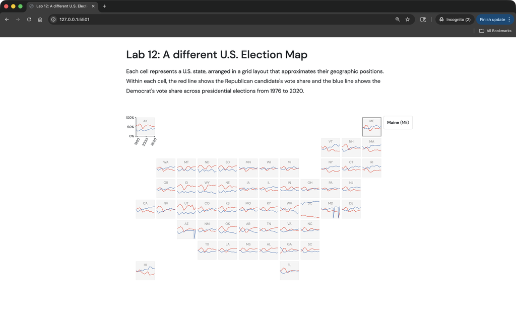

Final demo: The completed grid map with line charts, state labels, hover tooltip, and axes on Alaska.

## Part 1: Setup

### Project structure

1. Locate your `CMSC471` folder.
2. Create a new folder `lab12/`. Your folder should look like this:

```
lab12/
├── index.html
├── css/
│   └── styles.css
├── js/
│   └── script.js
└── data/
    ├── us-grid-map.json
    └── 1976-2020-president.csv
```

3. Download the two data files from [here](https://fumeng-yang.github.io/CMSC471/handouts/us-grid-map.json) and [here](https://fumeng-yang.github.io/CMSC471/handouts/1976-2020-president.csv) and place them in `data/`.
4. Start a local server:
   - VS Code: Click `Go Live`
   - Python 3: `python -m http.server 8000`; visit `http://localhost:8000`

### HTML skeleton

In `index.html`, set up Bootstrap, your stylesheet, a title, a paragraph, a tooltip placeholder, and a `#vis` div:

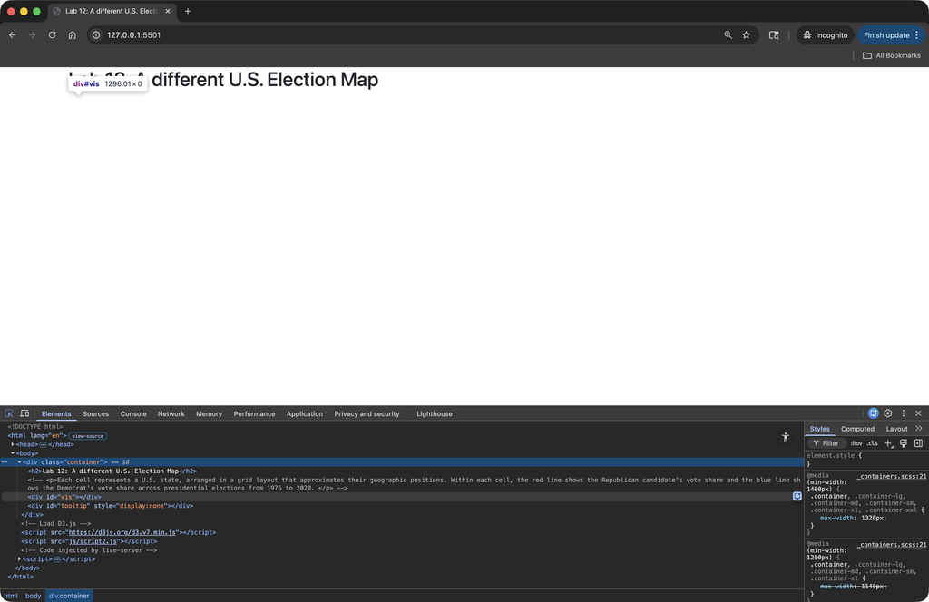

```html
<!DOCTYPE html>
<html lang="en">
<head>
    <meta charset="UTF-8">
    <title>Lab 12: A different U.S. Election Map</title>
    <link href="https://cdn.jsdelivr.net/npm/bootstrap@5.3.3/dist/css/bootstrap.min.css" ...>
    <link rel="stylesheet" href="css/styles.css">
</head>
<body>
    <div class="container">
        <h2>Lab 12: A different U.S. Election Map</h2>
        <div id="vis"></div>
        <div id="tooltip" style="display:none"></div>
    </div>
    <script src="https://d3js.org/d3.v7.min.js"></script>
    <script src="js/script.js"></script>
</body>
</html>
```

### Canvas setup

In `script.js`, set up your margins and SVG. We’ll use `viewBox` instead of fixed `width`/`height` so the chart scales with the browser window:

```javascript
const margin = { top: 20, right: 20, bottom: 20, left: 30 };
const width = 800 - margin.left - margin.right;
const height = 600 - margin.top - margin.bottom;

const svg = d3.select('#vis')
    .append('svg')
    .attr('viewBox', `0 0 ${width + margin.left + margin.right} ${height + margin.top + margin.bottom}`)
    .append('g')
    .attr('transform', `translate(${margin.left},${margin.top})`);
```

And in `styles.css`, make the SVG fill its container:

```css
* {
    font-family: DM Sans, sans-serif;
    margin: 0px auto;
    line-height: 1.8;
}
.container {
    max-width: 800px;
    margin: 2rem auto;
}

#vis svg {
    width: 100%;
    height: auto;
}
```

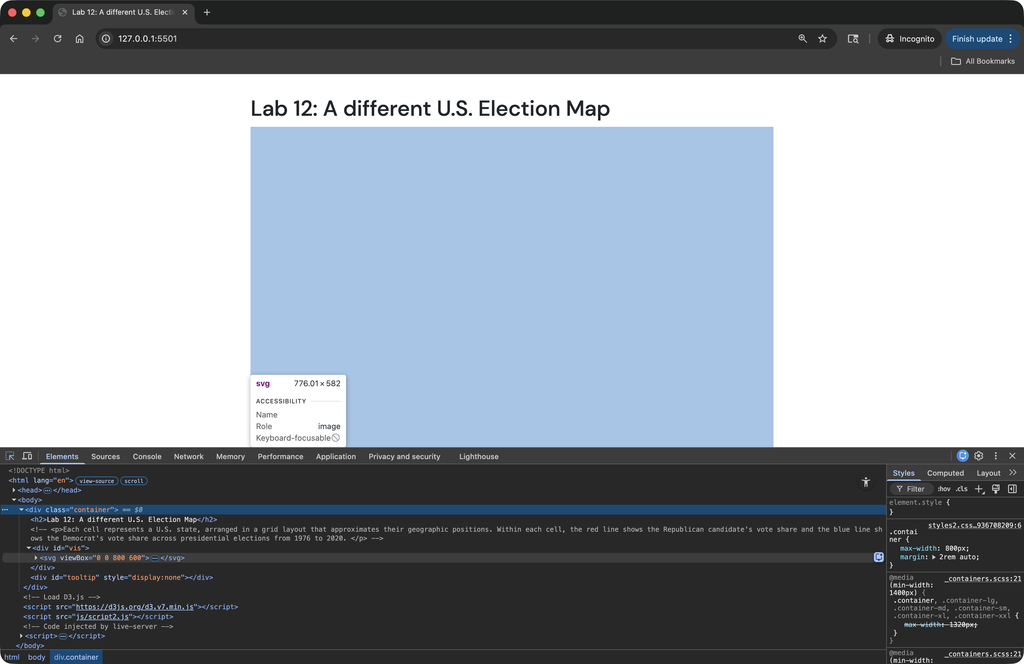

The SVG canvas is now set up with margins and a responsive viewBox.

## Part 2: Loading Data

This lab loads **two files** — a JSON and a CSV. We use `async/await` to wait for both before drawing anything.

### Using async/await

```javascript
window.addEventListener("load", init);

async function init() {
    const gridMap = await d3.json('data/us-grid-map.json');
    const electionData = await d3.csv('data/1976-2020-president.csv');
    console.log(gridMap);
    console.log(electionData);
    updateVis(gridMap, electionData)
}

function updateVis(map, electionData) {

}
```

Open DevTools → Console and inspect both objects. Notice that `electionData` loads all numbers as **strings** by default.

[figure not shown]

Both datasets loaded in the console — note that numeric fields are strings at this stage.

### Formatting the election data

We need to clean the CSV: convert numeric columns and compute the vote percentage per candidate.

```javascript
function formatData(data) {
    return data.map(d => ({
        stateFullName: d.state,
        state: d.state_po,           // two-letter abbreviation
        year: +d.year,
        party: d.party_detailed,
        candidatePerc: +d.candidatevotes / +d.totalvotes // compute vote share
    }));
}
```

**Your turn:** In `init()`, after calling `formatData()`, use `d3.min()` and `d3.max()` to compute `firstYear` and `lastYear` from the formatted data. Store these as global variables — you’ll need them in Part 3.

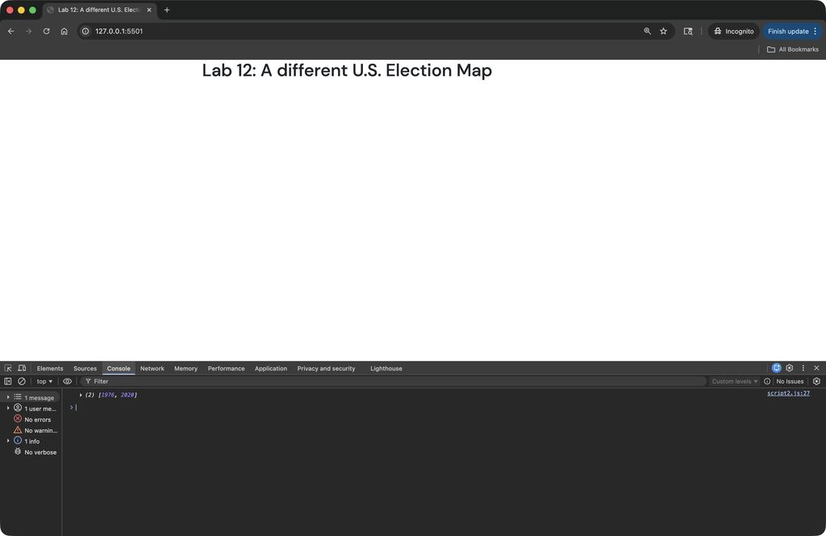

Console showing `[1976, 2020]` — confirming firstYear and lastYear are correct numbers.

```javascript
    let lastYear, firstYear
    ...
    async function init() {
         const gridMap = await d3.json('data/us-grid-map.json');
         const electionData = await d3.csv('data/1976-2020-president.csv');
         //console.log(gridMap);
         //console.log(electionData);

        const formattedElectionData = formatData(electionData);
        firstYear = ... // finish this yourself
        lastYear = ... // finish this yourself
        console.log([firstYear, lastYear])

        updateVis(gridMap, formattedElectionData) // change to formattedElectionData!

    }
```

## Part 3: Drawing the Grid Map

Now let’s draw the grid. Each state occupies one cell in a 12-column × 8-row grid. We’ll use a linear scale to convert grid coordinates (0–11, 0–7) into pixel positions.

### Defining the cell size

```javascript
const xScale = d3.scaleLinear()
    .domain([0, 12]) // slightly larger, you can try [0, 11] to see what happens!
    .range([0, width]);

const unit = xScale(1) - xScale(0); // width of one cell in pixels
```

`unit` is the key measurement. Every element in the grid (rectangles, lines, labels, axes) is sized and positioned relative to it.

### Centering the grid

The grid is 12 columns wide and 8 rows tall, but the canvas is wider and taller. To center it:

```javascript
const xOffset = (width - 12 * unit) / 2;
const yOffset = (height - 8 * unit) / 2;
svg.attr('transform', `translate(${margin.left + xOffset}, ${margin.top + yOffset})`);
```

### Drawing state rectangles

In `updateVis()`, bind the grid map data to `rect` elements:

```javascript
svg.selectAll('.state')
    .data(map)
    .join(enter =>
        enter.append('rect')
            .attr('class', 'state')
            .attr('x', d => d.x * unit)
            .attr('y', d => d.y * unit)
            .attr('width', unit * 0.9) // leave some space between states
            .attr('height', unit * 0.9) // leave some space between states
            .attr('fill', '#f5f5f5')
            .attr('stroke', '#eeeeee')
            .attr('id', d => 'state-' + d.key)
    );
```

Note the `0.9` factor — it leaves a small gap between cells so the grid reads as distinct panels.

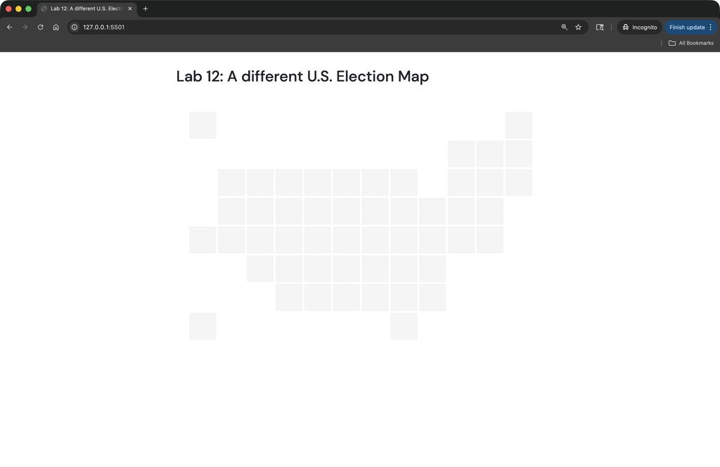

51 state cells arranged in a geographic grid, with small gaps between them.

## Part 4: Mini Line Charts

Here’s where small multiples come to life. For *each* state cell, we: 1. Filter the election data to that state 2. Define a *local* x and y scale that maps to that cell’s pixel bounds 3. Draw two lines: one Republican, one Democrat (Let’s ignore third-party candidates for now.)

### The `.each()` pattern

D3’s `.each()` lets you run a function for every element in a selection. Inside the function, `d` is the datum (a grid cell entry) and `this` is the DOM element (the `rect`). So in `updateVis()`

```javascript
svg.selectAll('.state')
    .each(function(d) {
        // d.key is the state abbreviation, e.g. "MD"
        // d.x, d.y are the grid position

        const stateElectionData = electionData.filter(e => e.state === d.key);
        // Now draw inside this state's cell...
        // ...
    });
```

### Local scales

Inside the `.each()` loop, each mini chart needs its own x and y scale that maps to that specific cell’s pixel bounds:

```javascript
const localXScale = d3.scaleLinear()
    .domain([firstYear, lastYear])
    .range([d.x * unit, (d.x + 0.9) * unit]);  // left to right edge of cell

const localYScale = d3.scaleLinear()
    .domain([0, 1])
    .range([(d.y + 0.9) * unit, d.y * unit]);   // bottom to top of cell (inverted!)
```

Why inverted? In SVG, y increases downward, but we want 0% at the bottom and 100% at the top.

### Drawing the lines

`d3.line()` is a **path generator** — you configure it once with `.x()` and `.y()` accessors, then call it on an array of data points and it returns an SVG path string ready for the `d` attribute. Think of it as a translator: data array in, path string out.

```javascript
const line = d3.line()
    .x(d => localXScale(d.year))          // map year → pixel x within the cell
    .y(d => localYScale(d.candidatePerc)); // map vote share → pixel y within the cell
```

We render only Republican and Democrat. We draw one path per party by looping over `["REPUBLICAN", "DEMOCRAT"]`, filtering the state’s data to just that party’s rows, and appending a `<path>`:

```javascript
const parties = ["REPUBLICAN", "DEMOCRAT"];

parties.forEach(party => {
    const partyData = stateElectionData.filter(d => d.party === party);
    svg.append("path")
        .attr("d", line(partyData))
        .attr("stroke", 'black') // black color for now
        .attr("stroke-width", "1px")
        .attr("fill", "none");  // lines have no fill — only the stroke matters
});
```

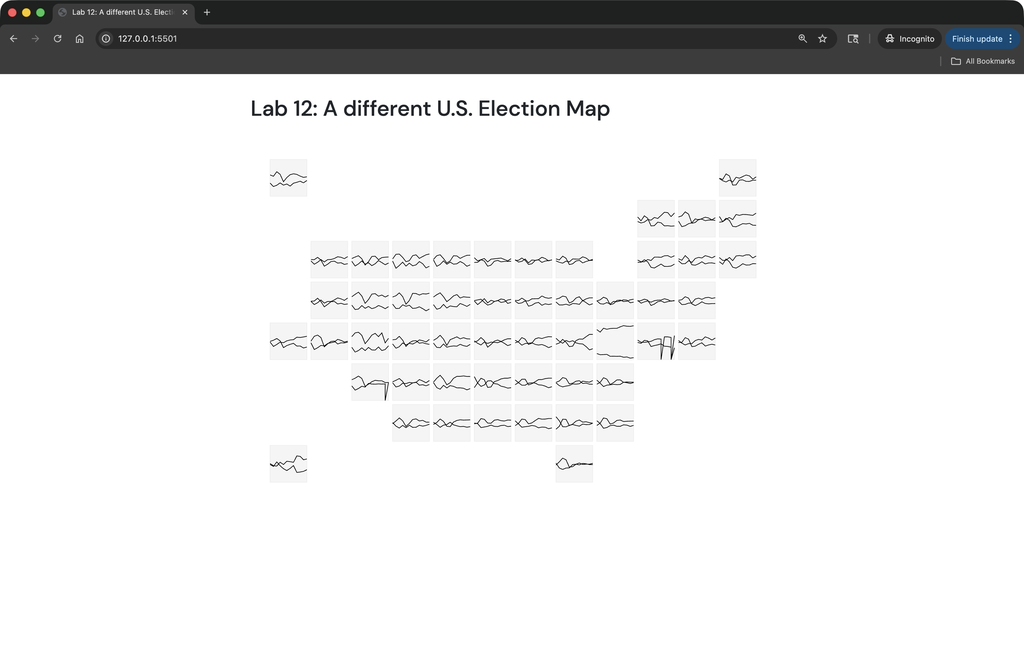

Line charts appear in every cell, all in black for now — the trend shapes are already visible.

**Your turn:** Define a `partyColor` object that maps each party name to a color (red for Republican, blue for Democrat), then use it in `.attr("stroke", ...)`.

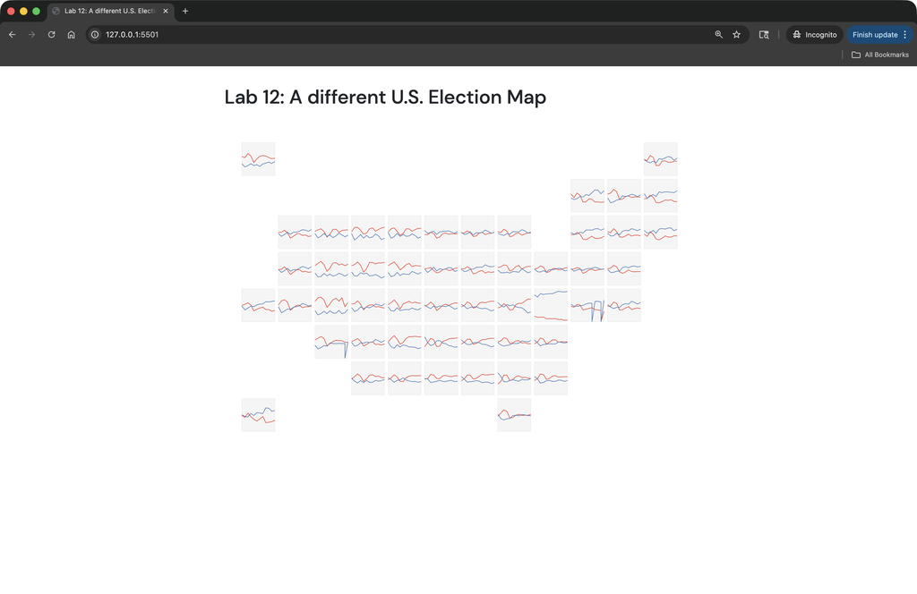

Red (Republican) and blue (Democrat) lines make party trends immediately readable.

## Part 5: Refinement

### Hover tooltip

A tooltip lets users identify states by hovering.

```css
#tooltip {
    position: absolute;
    padding: 8px 10px;
    background: white;
    border: 1px solid #ddd;
    border-radius: 4px;
    pointer-events: none;
    font-size: 12px;
}
```

Then attach mouse events to the `.state` rectangles inside `join()`:

```javascript
.on('mouseover', function(event, d) {
    d3.select(this).attr('stroke', '#999').attr('stroke-width', 2);
    d3.select('#tooltip')
        .style('display', 'block')
        .html(`<strong>${d.name}</strong> (${d.key})`)
        .style('left', (event.pageX + 12) + 'px')
        .style('top', (event.pageY - 20) + 'px');
})
.on('mousemove', function(event) {
    d3.select('#tooltip')
        .style('left', (event.pageX + 12) + 'px')
        .style('top', (event.pageY - 20) + 'px');
})
.on('mouseout', function() {
    d3.select(this).attr('stroke', '#eeeeee').attr('stroke-width', 1);
    d3.select('#tooltip').style('display', 'none');
})
```

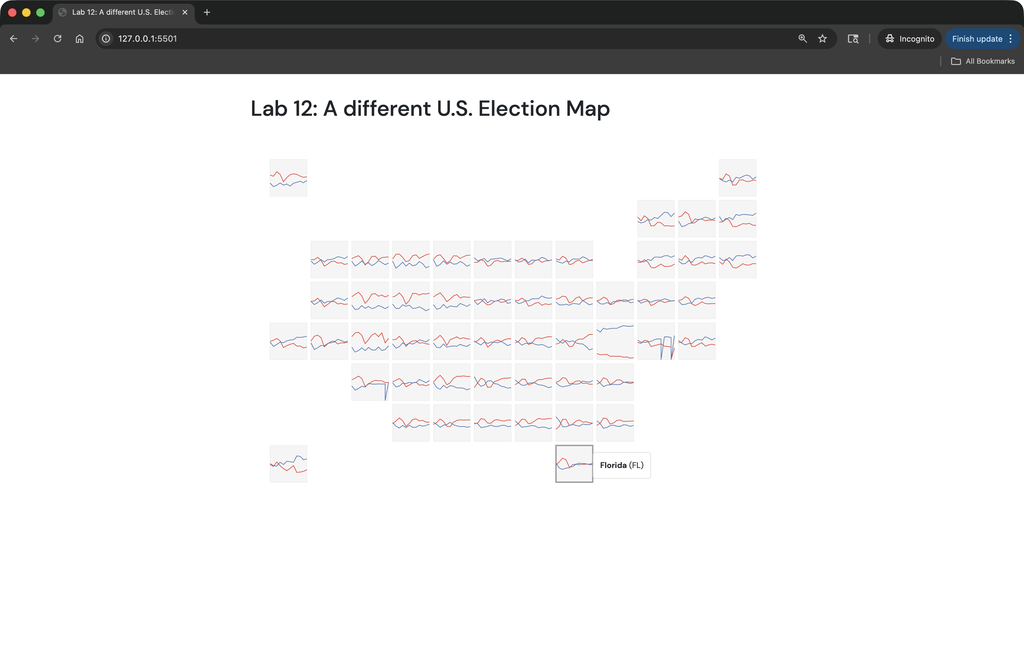

Hovering over a state highlights its border and shows the full state name in a tooltip.

### Axes for one state

To help users read the scale, we add axes to a single reference state (Alaska, top-left). There are multiple ways to do this. Here, looking inside `.each()`, check `if (d.key === 'AK')` and append an x and y axis using the local scales:

```javascript
if (d.key === 'AK') {
    const xAxis = d3.axisBottom(localXScale)
        .ticks(3)
        .tickFormat(d3.format('d'))
        .tickSize(3);

    const yAxis = d3.axisLeft(localYScale)
        .ticks(3)
        .tickFormat(d3.format('.0%'))
        .tickSize(3);

    svg.append('g')
        .attr('class', 'axis-state x-axis')
        .attr('transform', `translate(0, ${(d.y + 0.9) * unit})`)
        .call(xAxis)
        .selectAll('text')
        .attr('transform', 'rotate(-60)')
        .attr('text-anchor', 'end')
        .attr('dy', '0.4em')
        .attr('dx', '-0.4em');

    svg.append('g')
        .attr('class', 'axis-state y-axis')
        .attr('transform', `translate(${d.x * unit}, 0)`)
        .call(yAxis);
}
```

**Why Alaska?** It sits at grid position (0, 0) — top-left — where axes don’t overlap neighboring cells and there’s room in the margin.

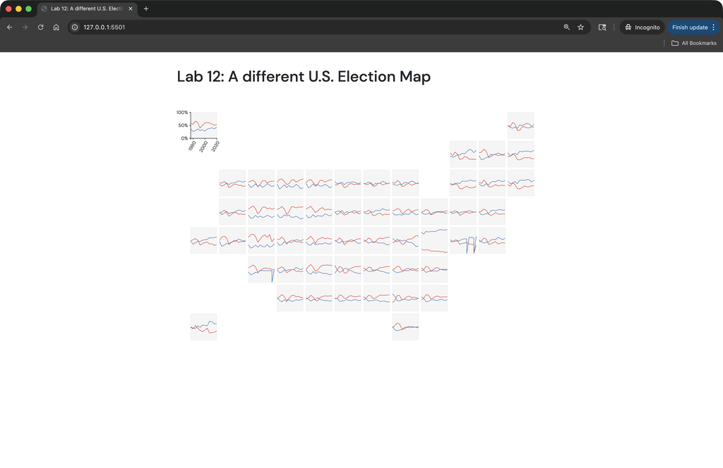

### Adding state labels

In `updateVis()`, each cell needs a two-letter label so the reader can identify the state at a glance. We append a `text` element for every state, centered near the top of its cell:

```javascript
svg.selectAll('.state-label')
    .data(map)
    .join(enter =>
        enter.append('text')
            .attr('class', 'state-label')
            .attr('x', d => d.x * unit + unit * 0.45)  // horizontal center of cell
            .attr('y', d => d.y * unit + unit * 0.22)  // near the top
            .attr('text-anchor', 'middle')
            .text(d => d.key)
    );
```

Style the labels in `styles.css` so they don’t block hover events on the rectangles beneath:

```css
.state-label {
    font-size: 10px;
    fill: #999999;
    pointer-events: none;
    user-select: none;
}
```

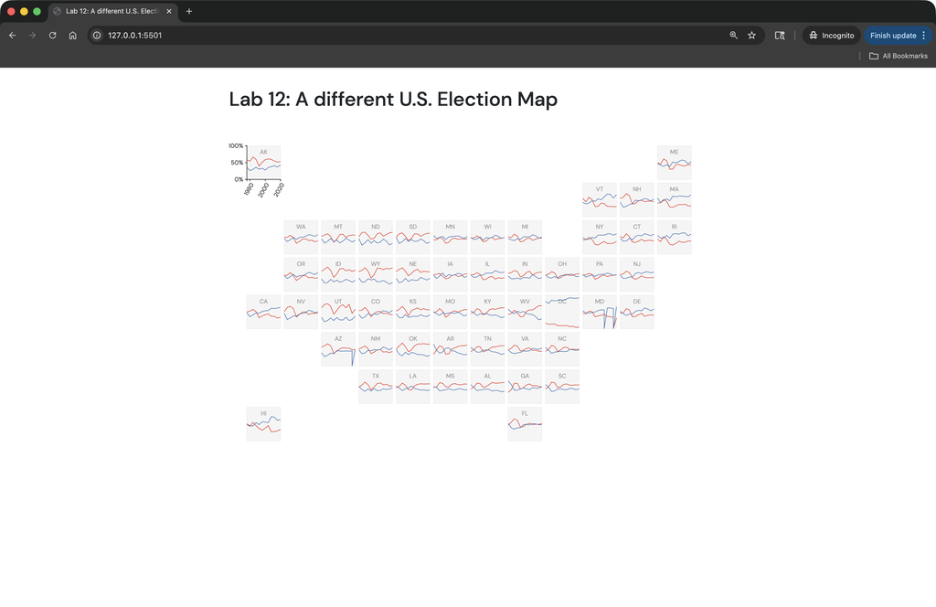

Two-letter abbreviations in each cell let readers identify states without hovering.

Remember to add a paragraph to explain the visualization. Now you should have a complete US election map!

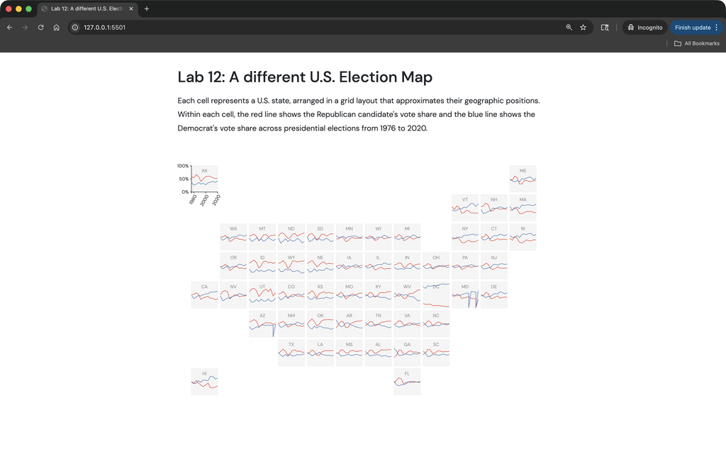

The complete visualization with all required features.

## Not required

Instead of a static hover that just shows the state name, we can make the interaction richer: as you move your mouse across a state cell, a vertical bar tracks your cursor and a tooltip updates in real time with the Republican and Democrat vote shares for that specific year.

Also, there is a bug in our data processing so sometimes the vote shares go down to 0.

Here is a demo:

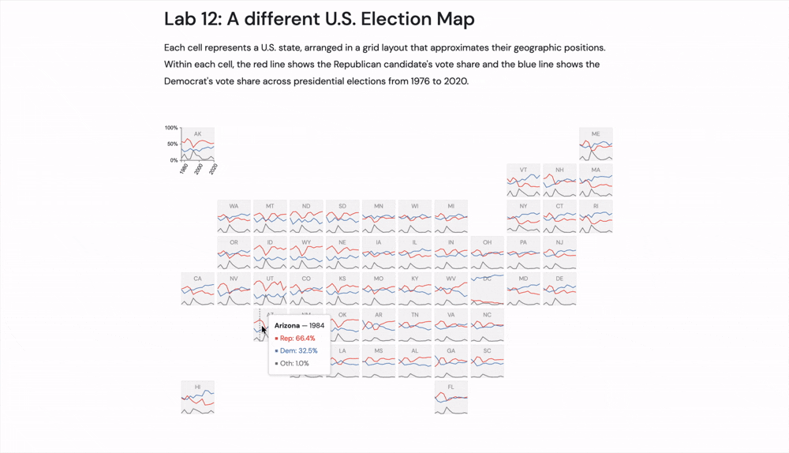

A vertical bar tracks the cursor across a state cell, updating the tooltip with the exact year and vote shares.

### Clues (not full code):

The key idea is **inverting a scale**. Every D3 scale has an `.invert()` method that reverses the mapping — given a pixel position, it returns the corresponding data value. Here we use it to convert the mouse’s x coordinate back into a year:

```javascript
const rawYear = localXScale.invert(mouseX);
```

Because elections only happen every four years, we then snap the raw year to the nearest election year:

```javascript
const year = Math.round((rawYear - firstYear) / 4) * 4 + firstYear;
```

To avoid creating a new bar element on every `mousemove` event (which would be expensive), we create a **single shared `<line>` element** once at the top and just reposition it:

```javascript
const hoverBar = svg.append('line').style('display', 'none'); // created once

// inside mousemove — just move it
hoverBar
    .style('display', null)
    .attr('x1', localXScale(year)).attr('x2', localXScale(year))
    .attr('y1', d.y * unit).attr('y2', (d.y + 0.9) * unit);
```

## Checklist ✓

Grid map displays all 51 state cells in the correct geographic positions.  
Two-letter state abbreviations are visible inside each cell.  
Red (Republican) and blue (Democrat) line charts appear inside each cell.  
Hovering over a state highlights it and shows its full name in a tooltip.  
Alaska (top-left cell) shows labeled x-axis (years) and y-axis (vote share).  
Add a paragraph to explain how to read the visualization.  
No console errors.

### AI usage

- **Track 1**: AI may be used for brainstorming, debugging, and explaining concepts. Using AI to directly generate the entire lab is prohibited — if identified, the lab receives a 66% score reduction and no resubmission will be accepted.
- **Track 2**: AI use is unrestricted. However, you must design your own prompt and not use this handout as a prompt — if identified, the lab receives a 66% score reduction and no resubmission will be accepted.
- **Conceptual understanding checks**: During lab checkouts, we will ask conceptual questions regardless of track. Repeated inability to answer will result in an additional 33% deduction.

## Submission process

- Raise your hand ✋
- Show the working webpage (grid map, line charts, hover, axes on AK)
- Let us skim your `script.js` and `console`
- Confirm your name

## Debugging tips

### Lines not appearing

- `console.log(partyData)` inside the loop — is it empty?
- Check that `firstYear`/`lastYear` are numbers, not strings
- Verify `localXScale.range()` and `localYScale.range()` match the cell bounds

### State cells misaligned

- Confirm the grid map JSON is loading correctly
- Check that `d.x` and `d.y` come from the JSON (not the election data)
- Print `unit` to the console — does it match your expected cell size?

### Tooltip not moving

- Make sure you have a `mousemove` handler in addition to `mouseover`
- Check that `#tooltip` has `position: absolute` in CSS

### Axes overflowing the cell

- Reduce `.ticks()` count
- Adjust font size on tick labels

## Resources

- [D3 line generator](https://d3js.org/d3-shape/line)
- [D3 `selection.each()`](https://d3js.org/d3-selection/control-flow#selection_each)
- [Small multiples with D3](https://www.d3indepth.com/layouts/)
- [MIT Election Lab data](https://electionlab.mit.edu/data)